# SISCER Survival Day 2

Pamela Shaw

2026-07-10

## Handling non-proportional hazards

This content is largely summarizing content from Terry Therneau’s vignette for time dependency at https://cran.r-project.org/web/packages/survival/vignettes/timedep.pdf

## Veteran data set in survival package

Let’s load the data and look at a few summaries. And fit a multivariable cox model for the association of treatment, prior therapy, and karnofsky score with the hazard for death.

```r
data(cancer, package="survival")
nrow(veteran)
```

```
## [1] 137
```

```r
head(veteran)
```

```
##   trt celltype time status karno diagtime age prior
## 1   1 squamous   72      1    60        7  69     0
## 2   1 squamous  411      1    70        5  64    10
## 3   1 squamous  228      1    60        3  38     0
## 4   1 squamous  126      1    60        9  63    10
## 5   1 squamous  118      1    70       11  65    10
## 6   1 squamous   10      1    20        5  49     0
```

```r
summary(veteran$karno)
```

```
##    Min. 1st Qu.  Median    Mean 3rd Qu.    Max.
##   10.00   40.00   60.00   58.57   75.00   99.00
```

```r
table(veteran$status) #number of deaths
```

```
##
##   0   1
##   9 128
```

```r
## mulltivariable cox model
vfit0 <- coxph(Surv(time, status) ~ trt + prior + karno, veteran)
summary(vfit0)
```

```
## Call:
## coxph(formula = Surv(time, status) ~ trt + prior + karno, data = veteran)
##
##   n= 137, number of events= 128
##
##            coef exp(coef)  se(coef)      z Pr(>|z|)
## trt    0.180197  1.197453  0.183468  0.982    0.326
## prior -0.005551  0.994464  0.020225 -0.274    0.784
## karno -0.033771  0.966793  0.005114 -6.604    4e-11 ***
## ---
## Signif. codes:  0 '***' 0.001 '**' 0.01 '*' 0.05 '.' 0.1 ' ' 1
##
##       exp(coef) exp(-coef) lower .95 upper .95
## trt      1.1975     0.8351    0.8358    1.7156
## prior    0.9945     1.0056    0.9558    1.0347
## karno    0.9668     1.0343    0.9572    0.9765
##
## Concordance= 0.713  (se = 0.022 )
## Likelihood ratio test= 43.04  on 3 df,   p=2e-09
## Wald test            = 44.94  on 3 df,   p=1e-09
## Score (logrank) test = 47.21  on 3 df,   p=3e-10
```

```r
# transformation to understand effect of 10 point increases
veteran$mykarno <- veteran$karno/10
vfit <- coxph(Surv(time, status) ~ trt + prior + mykarno, veteran)
summary(vfit)
```

```
## Call:
## coxph(formula = Surv(time, status) ~ trt + prior + mykarno, data = veteran)
##
##   n= 137, number of events= 128
##
##              coef exp(coef)  se(coef)      z Pr(>|z|)
## trt      0.180197  1.197453  0.183468  0.982    0.326
## prior   -0.005551  0.994464  0.020225 -0.274    0.784
## mykarno -0.337710  0.713402  0.051137 -6.604    4e-11 ***
## ---
## Signif. codes:  0 '***' 0.001 '**' 0.01 '*' 0.05 '.' 0.1 ' ' 1
##
##         exp(coef) exp(-coef) lower .95 upper .95
## trt        1.1975     0.8351    0.8358    1.7156
## prior      0.9945     1.0056    0.9558    1.0347
## mykarno    0.7134     1.4017    0.6454    0.7886
##
## Concordance= 0.713  (se = 0.022 )
## Likelihood ratio test= 43.04  on 3 df,   p=2e-09
## Wald test            = 44.94  on 3 df,   p=1e-09
## Score (logrank) test = 47.21  on 3 df,   p=3e-10
```

## Let’s assess the proportional hazards assumption

```r
vfit.ph <- cox.zph(vfit)
print(vfit.ph)
```

```
##          chisq df       p
## trt      0.288  1 0.59125
## prior    2.168  1 0.14087
## mykarno 12.138  1 0.00049
## GLOBAL  18.073  3 0.00042
```

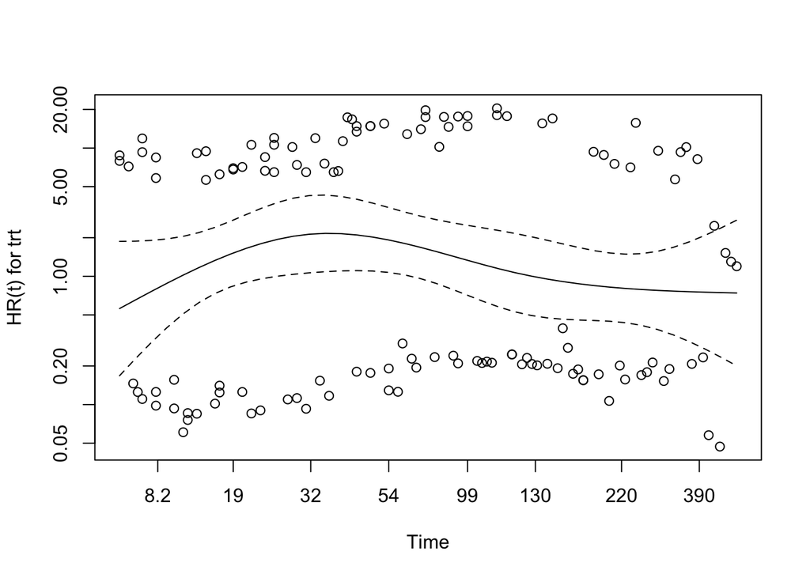

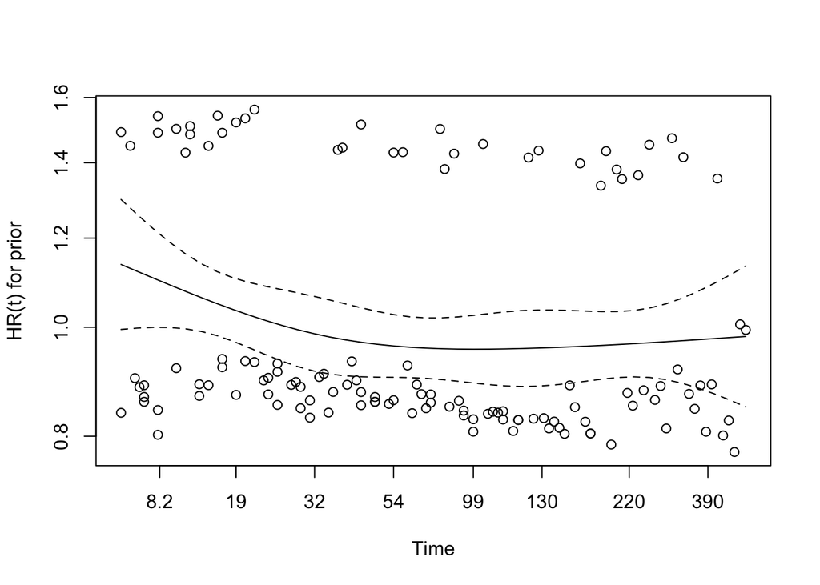

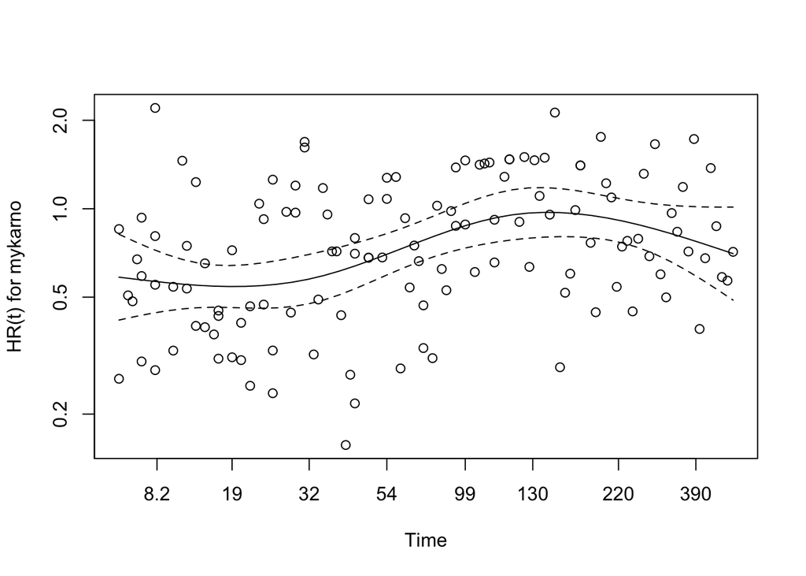

```r
plot(vfit.ph,hr=T)
```

We can see strong evidence of non-proportional hazards for the karnofsky score.

## Model approach 1: Have beta(t) for karno be a step function over different intervals: 3 months and 6 months (remember time measured in days so cut points are at 90 and 180 days)

```r
vet2 <- survSplit(Surv(time, status) ~ ., data= veteran, cut=c(90, 180),
                  episode= "tgroup", id="id")
vet2[1:7, c("id", "tstart", "time", "status", "tgroup", "age", "karno")]
```

```
##   id tstart time status tgroup age karno
## 1  1      0   72      1      1  69    60
## 2  2      0   90      0      1  64    70
## 3  2     90  180      0      2  64    70
## 4  2    180  411      1      3  64    70
## 5  3      0   90      0      1  38    60
## 6  3     90  180      0      2  38    60
## 7  3    180  228      1      3  38    60
```

```r
vfit2 <- coxph(Surv(tstart, time, status) ~ trt + prior + karno:strata(tgroup),
               data=vet2)
vfit2
```

```
## Call:
## coxph(formula = Surv(tstart, time, status) ~ trt + prior + karno:strata(tgroup),
##     data = vet2)
##
##                                   coef exp(coef)  se(coef)      z        p
## trt                          -0.011025  0.989035  0.189062 -0.058    0.953
## prior                        -0.006107  0.993912  0.020355 -0.300    0.764
## karno:strata(tgroup)tgroup=1 -0.048755  0.952414  0.006222 -7.836 4.64e-15
## karno:strata(tgroup)tgroup=2  0.008050  1.008083  0.012823  0.628    0.530
## karno:strata(tgroup)tgroup=3 -0.008349  0.991686  0.014620 -0.571    0.568
##
## Likelihood ratio test=63.04  on 5 df, p=2.857e-12
## n= 225, number of events= 128
```

This model suggests the effect of karnofsky score is really only important in first few months. If this score measures an acute illness, then it makes sense that the baseline score would be less important later on.

## We can check the PH assumption

We can use `cox.zph()` to check to see if there is still evidence of a time-varying effect for this variable.

```r
cox.zph(vfit2)
```

```
##                      chisq df     p
## trt                   1.72  1 0.189
## prior                 3.81  1 0.051
## karno:strata(tgroup)  3.04  3 0.385
## GLOBAL                8.03  5 0.154
```

The `cox.zph()` results shows no further time dependent effect of Karnofsky score. Since we used the original graph to pick the cut points, this post-hoc result needs to be viewed with caution.

## Visualizing what the model says about survival

*(again leaning heavily on Therneau’s vignette)*

When plotting survival curves from a fitted Cox model, the default is to estimate the curve for the average covariate value. For treatment, and other categorical variables (e.g. sex) this doesn’t make much sense. Instead we will create a hypothetical data set “with the three time intervals for two hypothetical subjects labeled as ‘curve 1’ and ‘curve 2.’ One has a Karnofsky of 40 and the other a Karnofsky of 75, both on treatment 1 and with no prior therapy. Each has the appropriate values for the time dependent covariate tgroup, which is 1, 2, 3 over 0–90, 90–180 and 180+ days, respectively. We will draw curves for the first year.”

Below we will plot the fitted curves for these two indivudals (dotted lines) and compare to the Kaplan-Meier survival curves for groups with a karnofsky score above and below the median (solid lines).

```r
quantile(veteran$karno)
```

```
##   0%  25%  50%  75% 100%
##   10   40   60   75   99
```

```r
cdata <- data.frame(tstart= rep(c(0,90,180), 2),
  time = rep(c(90,180, 365), 2),
  status= rep(0,6), #necessary, but ignored
  tgroup= rep(1:3, 2),
  trt = rep(1,6),
  prior= rep(0,6),
  karno= rep(c(40, 75), each=3),
  curve= rep(1:2, each=3))

cdata
```

```
##   tstart time status tgroup trt prior karno curve
## 1      0   90      0      1   1     0    40     1
## 2     90  180      0      2   1     0    40     1
## 3    180  365      0      3   1     0    40     1
## 4      0   90      0      1   1     0    75     2
## 5     90  180      0      2   1     0    75     2
## 6    180  365      0      3   1     0    75     2
```

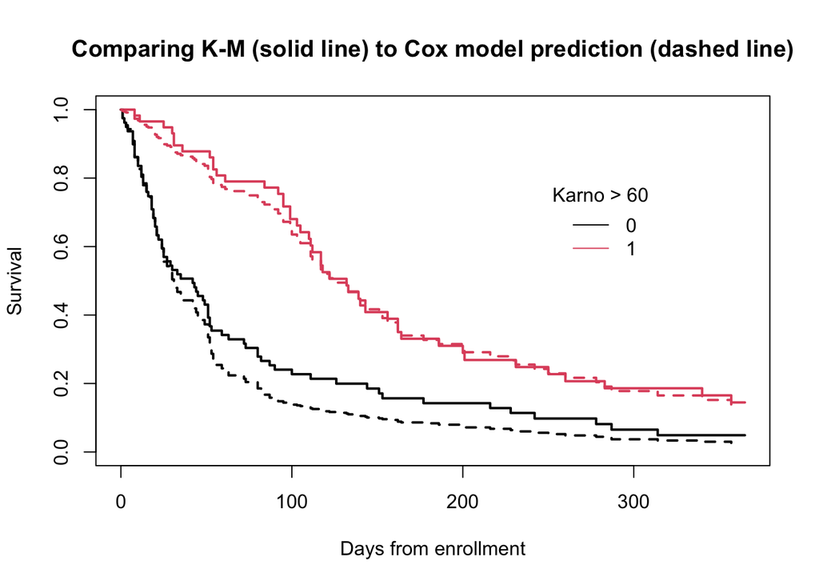

```r
sfit <- survfit(vfit2, newdata=cdata, id=curve)
km <- survfit(Surv(time, status) ~ I(karno>60), veteran)

plot(km, xmax= 365, col=1:2, lwd=2, xlab="Days from enrollment",
     ylab="Survival")
legend(250, .8, c("0", "1"),col=1:2,lty=1,bty="n",title="Karno > 60")
lines(sfit, col=1:2, lty=2, lwd=2)
title("Comparing K-M (solid line) to Cox model prediction (dashed line)")
```

## Model approach 2: Model beta(t) for karno as a function of time

For sake of an example, let’s try $\beta(t) = a + b \;log(t)$. This transformation is often chosen, which will increase more slowly as time gets larger. That likely is better than a simple linear transformation in this context. Recall the `cox.zph()` approximation of $\beta(t)$ for karno with confidence intervals, with added horizontal lines for the null (red dashed) and the fitted beta (red dotted).

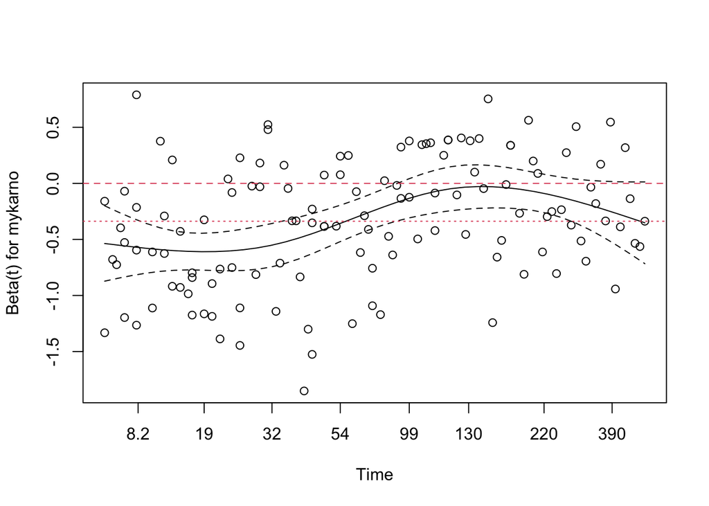

```r
vfit <- coxph(Surv(time, status) ~ trt + prior + mykarno, veteran)
plot(vfit.ph[3])
abline(h=0, col=2,lty=2) #null
abline(h=vfit$coef[3],lty=3,col=2) #fitted coef for karno
```

We can use the `cox.zph()` function to examine coefficient of karno on the scale $\log(20+t)$, which we will see below produces an approximate linear function for beta for the first 200 days.

```r
vfit <- coxph(Surv(time, status) ~ trt + prior + karno, veteran)
zp <- cox.zph(vfit, transform= function(time) log(time +20))
zp
```

```
##         chisq df       p
## trt     0.271  1 0.60247
## prior   2.260  1 0.13275
## karno  10.694  1 0.00107
## GLOBAL 16.881  3 0.00075
```

We can now fit the Cox model allowing the coefficient for karno to vary by $\log(20+t)$, that is let $\beta(t)= a + b \log(t+20)$. This model finds $a$ and $b$ along with the time-invariant coefficients for the other covariates.

```r
vfit3 <- coxph(Surv(time, status) ~ trt + prior + karno + tt(karno),
               data = veteran, tt = function(x, t, ...) x * log(t+20))
vfit3
```

```
## Call:
## coxph(formula = Surv(time, status) ~ trt + prior + karno + tt(karno),
##     data = veteran, tt = function(x, t, ...) x * log(t + 20))
##
##                coef exp(coef)  se(coef)      z        p
## trt        0.016478  1.016614  0.190707  0.086  0.93115
## prior     -0.009317  0.990726  0.020296 -0.459  0.64619
## karno     -0.124662  0.882795  0.028785 -4.331 1.49e-05
## tt(karno)  0.021310  1.021538  0.006607  3.225  0.00126
##
## Likelihood ratio test=53.84  on 4 df, p=5.698e-11
## n= 137, number of events= 128
```

**Very important:** In order to add a true time-varying coefficient and not just add time as a covariate in the model, you need the `tt()` function in R. Similar issues exist in other software.

The resulting fitted time-varying coefficient for karno is estimated as $\beta(t) = -0.125 + 0.021 * \log(t + 20)$

We can see how well the fitted line is doing by adding it to the `cox.zph()` plot for the karno coefficient.

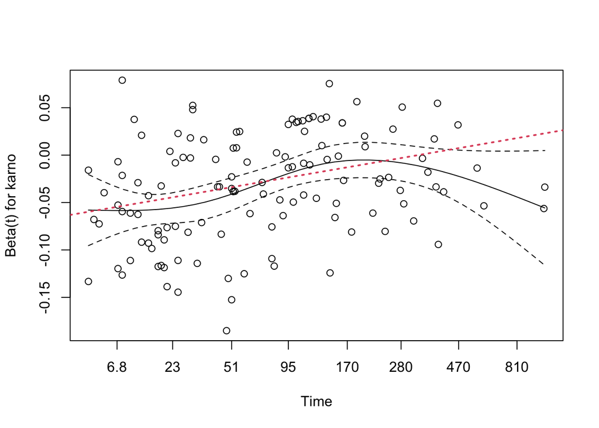

```r
plot(zp[3])
abline(coef(vfit3)[3:4], lwd=2, lty=3, col=2)
```

We can also implement a spline approach.

```r
vfit4 <- coxph(Surv(time, status) ~ trt + prior + karno + tt(karno),
               data=veteran,
               tt = function(x, t, ...) x* nsk(t, knots=c(5, 100, 200, 400),
                                               Boundary.knots = FALSE))
vfit4
```

```
## Call:
## coxph(formula = Surv(time, status) ~ trt + prior + karno + tt(karno),
##     data = veteran, tt = function(x, t, ...) x * nsk(t, knots = c(5,
##         100, 200, 400), Boundary.knots = FALSE))
##
##                 coef exp(coef)  se(coef)      z        p
## trt        -0.025937  0.974397  0.191034 -0.136 0.892003
## prior      -0.005787  0.994229  0.020299 -0.285 0.775556
## karno      -0.059583  0.942157  0.009414 -6.329 2.46e-10
## tt(karno)1  0.048253  1.049436  0.016281  2.964 0.003039
## tt(karno)2  0.062323  1.064306  0.016736  3.724 0.000196
## tt(karno)3  0.040798  1.041642  0.020558  1.985 0.047197
##
## Likelihood ratio test=59.02  on 6 df, p=7.111e-11
## n= 137, number of events= 128
```

The plot functions for cox.zph() dont work well with a spline so could look at the spline outside this function

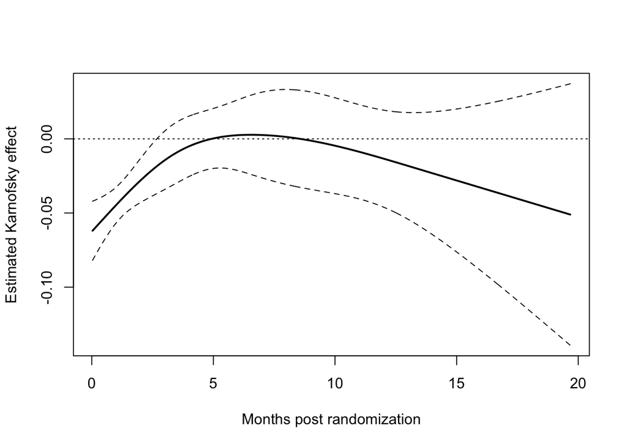

```r
smat <- cbind(1, nsk(1:600, knots=c(100, 200), Boundary.knots = c(5,400)))
estimate <- smat%*% coef(vfit4)[3:6]
sd.est <- sqrt(diag(smat %*% vcov(vfit4)[3:6, 3:6] %*% t(smat)))
ytemp <- c(estimate) + outer(sd.est, c(0, -1.96, 1.96), '*')
matplot(1:600/30.5, ytemp, type='l', lty=c(1,2,2), lwd=c(2,1,1), col=1,
xlab="Months post randomization", ylab="Estimated Karnofsky effect")
abline(0,0, lty=3)
```

In first 5 months, we see coeffient effect decrease in magnitude towards zero, with very wide CI beyond for the beta coefficient beyond that.

# Competing risks

MGUS analysis from https://cran.r-project.org/web/packages/survival/vignettes/compete.

## MGUS: Overall survival

Analysis of overall survival, follows as before. Females appear to have a higher overall survival.

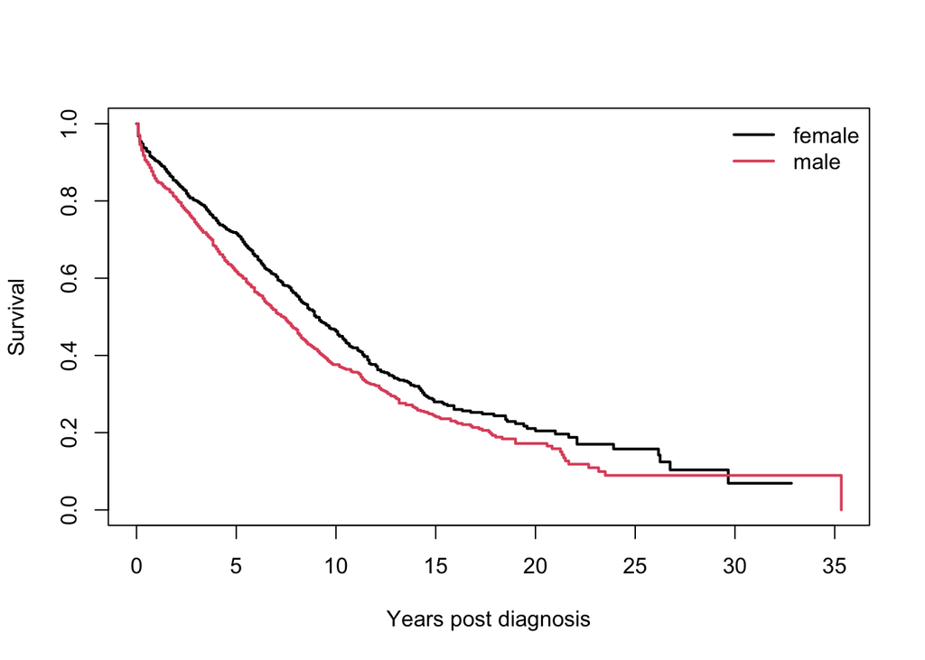

```r
mfit1 <- survfit(Surv(futime, death) ~ sex, data=mgus2)

plot(mfit1, col=c(1,2), xscale=12, mark.time=FALSE,
     lwd=2, xlab="Years post diagnosis", ylab="Survival")
legend("topright",c("female", "male"), col=1:2, lwd=2, bty='n')
```

```r
survdiff(Surv(futime, death) ~ sex, data=mgus2)
```

```
## Call:
## survdiff(formula = Surv(futime, death) ~ sex, data = mgus2)
##
##         N Observed Expected (O-E)^2/E (O-E)^2/V
## sex=F 631      423      471      4.88      9.67
## sex=M 753      540      492      4.67      9.67
##
##  Chisq= 9.7  on 1 degrees of freedom, p= 0.002
```

## MGUS: Competing risks cumulative incidence

Here we are coding 0=censoring, 2=death, 1=competing risk.

```r
mgus2$etime <- with(mgus2, ifelse(pstat==0, futime, ptime))
event <- with(mgus2, ifelse(pstat==0, 2*death, 1))
mgus2$event <- factor(event, 0:2, labels=c("censor", "pcm", "death"))

## print out some summaries
# let's look at sample id for someone who had both a PCM and death
mgus2[mgus2$id==56,]
```

```
##    id age sex dxyr  hgb creat mspike ptime pstat futime death etime event
## 56 56  78   M 1978 10.3     3    1.9    29     1     44     1    29   pcm
```

```r
### check number of rows and investigate number of events
nrow(mgus2)
```

```
## [1] 1384
```

```r
table(mgus2$event)
```

```
##
## censor    pcm  death
##    409    115    860
```

```r
sum(table(mgus2$event))
```

```
## [1] 1384
```

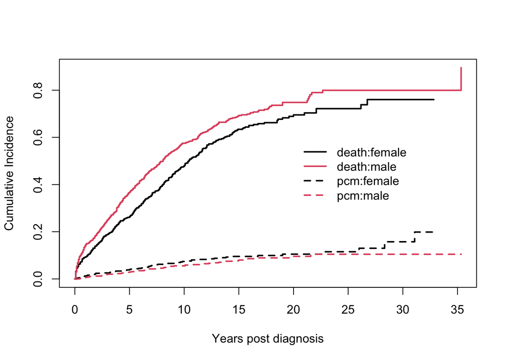

```r
#### now ce can plot the cumulative incidence curves. Survfit knows to do this based on their being 3 event types.
mfit2 <- survfit(Surv(etime, event) ~ sex, data=mgus2)
plot(mfit2, col=c(1,2,1,2), lty=c(2,2,1,1), mark.time=FALSE, lwd=2, xscale=12,
     xlab="Years post diagnosis", ylab="Cumulative Incidence")
legend(240, .6, c("death:female", "death:male", "pcm:female", "pcm:male"),
col=c(1,2,1,2), lty=c(1,1,2,2), lwd=2, bty='n')
```

```r
print(mfit2, rmean=240, scale=12)
```

```
## Call: survfit(formula = Surv(etime, event) ~ sex, data = mgus2)
##
##                n nevent     rmean se(rmean)*
## sex=F, (s0)  631      0  9.853608  0.2909061
## sex=M, (s0)  753      0  8.675012  0.2627185
## sex=F, pcm   631     59  1.323284  0.1742312
## sex=M, pcm   753     56  1.064693  0.1417536
## sex=F, death 631    370  8.823108  0.3053757
## sex=M, death 753    490 10.260294  0.2825688
##    *restricted mean time in state (max time = 20 )
```

```r
### nice part of the fit, you can look at the totals for the different ways people had events/censoring
mfit2$transitions
```

```
##        to
## from    pcm death (censored)
##   (s0)  115   860        409
##   pcm     0     0          0
##   death   0     0          0
```

## Mistake if you use 1-KM for the cumulative incidence

Here we could naively use the indicator for pcm (pstat=1 or 0) and plot kaplan-meier curves. We can compare the 1-KM for pcm and see that it is inflated.

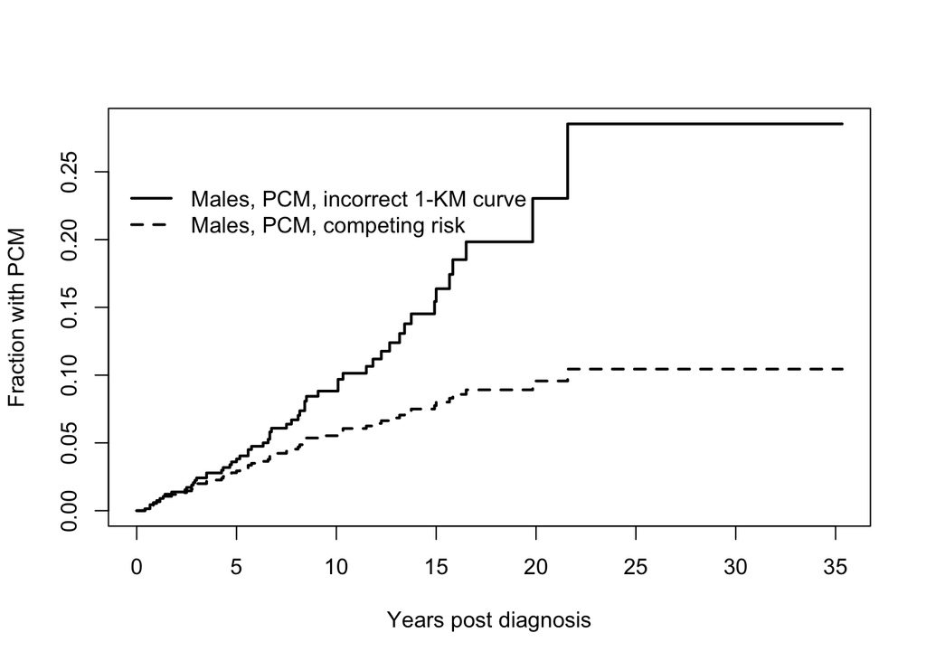

```r
pcmbad <- survfit(Surv(etime, pstat) ~ sex, data=mgus2)
plot(pcmbad[2], lwd=2, fun="event", conf.int=FALSE, xscale=12,
     xlab="Years post diagnosis", ylab="Fraction with PCM")
lines(mfit2[2,"pcm"], lty=2, lwd=2, mark.time=FALSE, conf.int=FALSE)
legend(-15, .25, c("Males, PCM, incorrect 1-KM curve", "Males, PCM, competing risk"),
       col=1, lwd=2, lty=c(1,2), bty='n')
```

## More informative CI plots from `tidycmprisk` package

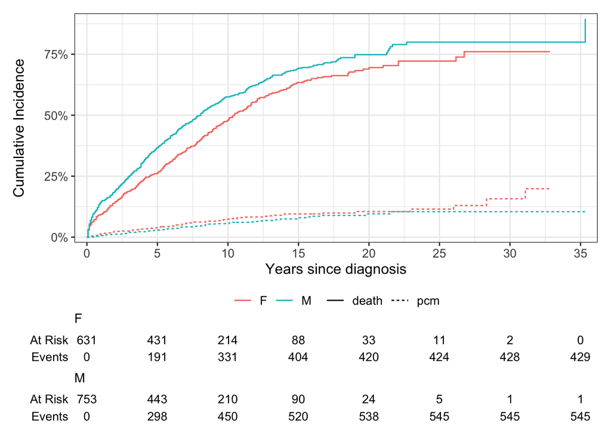

```r
mgus2$eyears <- mgus2$etime/12

cuminc(Surv(eyears, event) ~ sex, data=mgus2) %>%
  ggcuminc(outcome = c("death", "pcm")) +
  add_risktable() +
  scale_ggsurvfit() +labs(x="Years since diagnosis")
```

## MGUS: Multistate Model Model

### Contrary to the traditional competing risk approach, in a multstate model PCM is no longer treated as an absorbing state. You can transition from PCM to death and model that transition. The function tmerge() sets up the dataset for this model

```r
## need to break ties between PCM and death, assume PCM happens first
## this was done silently by survfit above
ptemp <- with(mgus2, ifelse(ptime==futime & pstat==1, ptime-.1, ptime))
data3 <- tmerge(mgus2, mgus2, id=id, death=event(futime, death),
                pcm = event(ptemp, pstat))

# Counting number of events a person experiences
data3 <- tmerge(data3, data3, id, enum=cumtdc(tstart))
with(data3, table(death, pcm))
```

```
##      pcm
## death   0   1
##     0 421 115
##     1 963   0
```

```r
temp <- with(data3, ifelse(death==1, 2, pcm))

# Need event to be a factor
data3$event <- factor(temp, 0:2, labels=c("censor", "pcm", "death"))
mfit3 <- survfit(Surv(tstart, tstop, event) ~ sex, data=data3, id=id)
print(mfit3, rmean=240, digits=2)
```

```
## Call: survfit(formula = Surv(tstart, tstop, event) ~ sex, data = data3,
##     id = id)
##
##                n nevent rmean se(rmean)*
## sex=F, (s0)  690      0 118.2       3.49
## sex=M, (s0)  809      0 104.1       3.15
## sex=F, pcm   690     59   3.2       0.59
## sex=M, pcm   809     56   2.7       0.62
## sex=F, death 690    423 118.6       3.48
## sex=M, death 809    540 133.2       3.19
##    *restricted mean time in state (max time = 240 )
```

```r
# Now can see folks can transition form PCM to death state
mfit3$transitions
```

```
##        to
## from    pcm death (censored)
##   (s0)  115   860        409
##   pcm     0   103         12
##   death   0     0          0
```

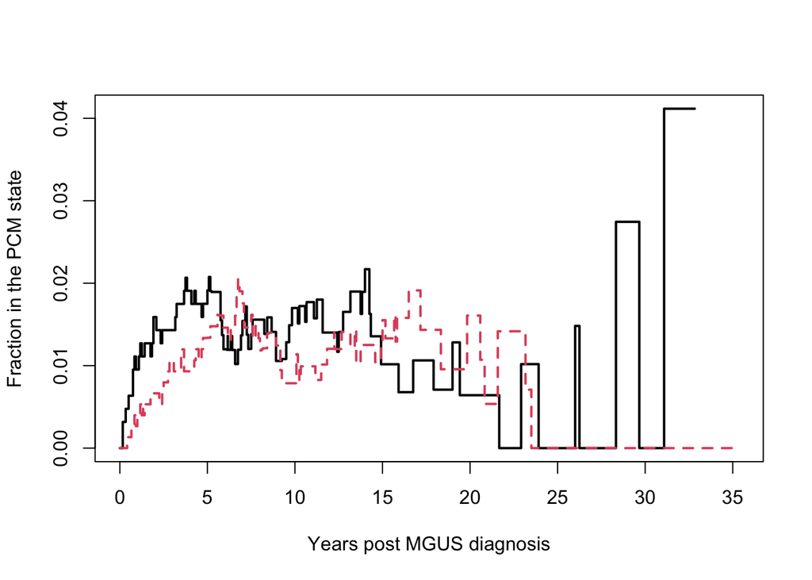

```r
# This is a different kind of plot, it is showing time in state
# There is now less time in pcm than before as its not an aborbing state
plot(mfit3[,"pcm"], mark.time=FALSE, col=1:2, lty=1:2, lwd=2,
     xscale=12, xlab="Years post MGUS diagnosis", ylab="Fraction in the PCM state")
legend(40, .4, c("female", "male"), lty=1:2, col=1:2, lwd=2, bty='n')
```

### Multistate: A different way of looking at things.

In this approach, you think about probablity of being in each state. Since you can transition from one to the other, these states are not mutually exclusive. You can also decide that death after PCM is a different state than death without PCM.

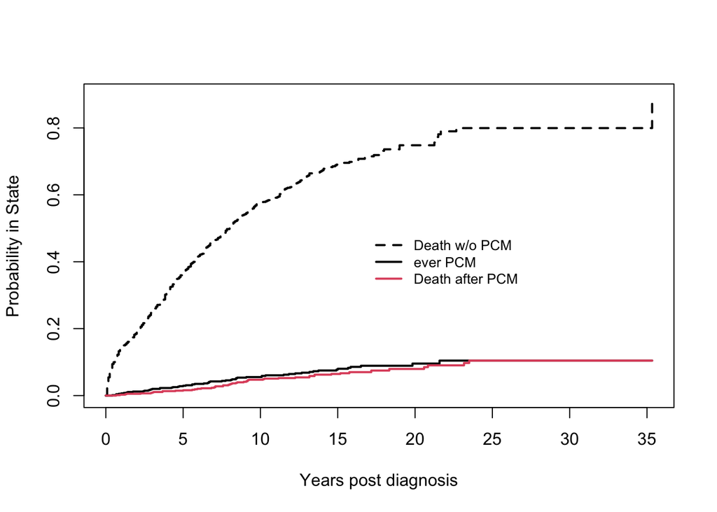

```r
# Death after PCM will correspond to data rows with
# enum = 2 and event = death. We make this the 4th state
d2 <- with(data3, ifelse(enum==2 & event=='death', 4, as.numeric(event)))
e2 <- factor(d2, labels=c("censor", "pcm", "death w/o pcm", "death after pcm"))

mfit4 <- survfit(Surv(tstart, tstop, e2) ~ sex, data=data3, id=id)

plot(mfit2[2,], lty=c(1,2), xscale=12, mark.time=FALSE, lwd=2,
     xlab="Years post diagnosis", ylab="Probability in State")
lines(mfit4[2,4], mark.time=FALSE, col=2, lty=1, lwd=2, conf.int=FALSE)
legend(200, .5, c("Death w/o PCM", "ever PCM", "Death after PCM"), col=c(1,1,2),
       lty=c(2,1,1), lwd=2, bty='n', cex=.82)
```

### Let’s go back to mgus2 dataset our competing risk modeling with 3 end states: censor, PCM, death

## MGUS: comparing CI Curves

- Can fit the Fine and Gray model with a single covariate using coxph().
- To do this need you first transform your data using the `finegray()` command in **survival** package to create a dataset for each competing risk you would like to test for covariate effects. Weights will also be created.

## MGUS: Gray’s Test and the Fine and Gray model

- In each dataset created by *finegray*, four new variables have been added containing a survival time (fgstart, fgstop, fgstatus) with an ‘ordinary’ status of 0/1, along with a case weight and a large number of new rows.
- A weighted Cox model fit to the constructed data set yields the Fine-Gray models for PCM and for death.
- The score test in the univariable model is Gray’s test.

```r
pcmdat <- finegray(Surv(etime, event) ~ ., data=mgus2, etype="pcm")
deathdat <- finegray(Surv(etime, event) ~ ., data=mgus2, etype="death")

fgPCM <- coxph(Surv(fgstart, fgstop, fgstatus) ~ sex, data=pcmdat,
               weights= fgwt)
summary(fgPCM)
```

```
## Call:
## coxph(formula = Surv(fgstart, fgstop, fgstatus) ~ sex, data = pcmdat,
##     weights = fgwt)
##
##   n= 41775, number of events= 115
##
##         coef exp(coef) se(coef) robust se      z Pr(>|z|)
## sexM -0.2290    0.7953   0.1866    0.1813 -1.263    0.207
##
##      exp(coef) exp(-coef) lower .95 upper .95
## sexM    0.7953      1.257    0.5574     1.135
##
## Concordance= 0.528  (se = 0.024 )
## Likelihood ratio test= 1.51  on 1 df,   p=0.2
## Wald test            = 1.6  on 1 df,   p=0.2
## Score (logrank) test = 1.51  on 1 df,   p=0.2,   Robust = 1.57  p=0.2
##
##   (Note: the likelihood ratio and score tests assume independence of
##      observations within a cluster, the Wald and robust score tests do not).
```

```r
fgDeath <- coxph(Surv(fgstart, fgstop, fgstatus) ~ sex, data=deathdat,
                 weights= fgwt)
summary(fgDeath)
```

```
## Call:
## coxph(formula = Surv(fgstart, fgstop, fgstatus) ~ sex, data = deathdat,
##     weights = fgwt)
##
##   n= 12910, number of events= 860
##
##         coef exp(coef) se(coef) robust se     z Pr(>|z|)
## sexM 0.23349   1.26299  0.06894   0.06427 3.633  0.00028 ***
## ---
## Signif. codes:  0 '***' 0.001 '**' 0.01 '*' 0.05 '.' 0.1 ' ' 1
##
##      exp(coef) exp(-coef) lower .95 upper .95
## sexM     1.263     0.7918     1.114     1.433
##
## Concordance= 0.535  (se = 0.009 )
## Likelihood ratio test= 11.57  on 1 df,   p=7e-04
## Wald test            = 13.2  on 1 df,   p=3e-04
## Score (logrank) test = 11.52  on 1 df,   p=7e-04,   Robust = 13.24  p=3e-04
##
##   (Note: the likelihood ratio and score tests assume independence of
##      observations within a cluster, the Wald and robust score tests do not).
```

```r
## Checking PH
cox.zph(fgPCM)
```

```
##        chisq df    p
## sex    0.252  1 0.62
## GLOBAL 0.252  1 0.62
```

```r
cox.zph(fgDeath)
```

```
##        chisq df     p
## sex      2.8  1 0.095
## GLOBAL   2.8  1 0.095
```

Note the same model can be fit using crr() in the cmprisk package.

## MGUS: Multivariable Fine and Gray

```r
fgPCM2 <- coxph(Surv(fgstart, fgstop, fgstatus) ~ age + sex + mspike,
                data=pcmdat, weights= fgwt)
summary(fgPCM2)
```

```
## Call:
## coxph(formula = Surv(fgstart, fgstop, fgstatus) ~ age + sex +
##     mspike, data = pcmdat, weights = fgwt)
##
##   n= 41429, number of events= 115
##    (346 observations deleted due to missingness)
##
##             coef exp(coef)  se(coef) robust se      z Pr(>|z|)
## age    -0.016861  0.983280  0.007056  0.005616 -3.002  0.00268 **
## sexM   -0.213124  0.808056  0.187090  0.180180 -1.183  0.23687
## mspike  0.888399  2.431234  0.156868  0.148638  5.977 2.27e-09 ***
## ---
## Signif. codes:  0 '***' 0.001 '**' 0.01 '*' 0.05 '.' 0.1 ' ' 1
##
##        exp(coef) exp(-coef) lower .95 upper .95
## age       0.9833     1.0170    0.9725    0.9942
## sexM      0.8081     1.2375    0.5676    1.1503
## mspike    2.4312     0.4113    1.8168    3.2535
##
## Concordance= 0.654  (se = 0.026 )
## Likelihood ratio test= 38.15  on 3 df,   p=3e-08
## Wald test            = 48.41  on 3 df,   p=2e-10
## Score (logrank) test = 39.99  on 3 df,   p=1e-08,   Robust = 33.17  p=3e-07
##
##   (Note: the likelihood ratio and score tests assume independence of
##      observations within a cluster, the Wald and robust score tests do not).
```

```r
fgDeath2 <- coxph(Surv(fgstart, fgstop, fgstatus) ~ age + sex + mspike,
                  data=deathdat, weights= fgwt)
summary(fgDeath2)
```

```
## Call:
## coxph(formula = Surv(fgstart, fgstop, fgstatus) ~ age + sex +
##     mspike, data = deathdat, weights = fgwt)
##
##   n= 12899, number of events= 854
##    (11 observations deleted due to missingness)
##
##             coef exp(coef)  se(coef) robust se      z Pr(>|z|)
## age     0.059060  1.060839  0.003570  0.003415 17.295  < 2e-16 ***
## sexM    0.369110  1.446447  0.069706  0.060299  6.121 9.28e-10 ***
## mspike -0.154313  0.857004  0.062099  0.054153 -2.850  0.00438 **
## ---
## Signif. codes:  0 '***' 0.001 '**' 0.01 '*' 0.05 '.' 0.1 ' ' 1
##
##        exp(coef) exp(-coef) lower .95 upper .95
## age        1.061     0.9427    1.0538     1.068
## sexM       1.446     0.6913    1.2852     1.628
## mspike     0.857     1.1669    0.7707     0.953
##
## Concordance= 0.67  (se = 0.01 )
## Likelihood ratio test= 336.8  on 3 df,   p=<2e-16
## Wald test            = 333  on 3 df,   p=<2e-16
## Score (logrank) test = 294.8  on 3 df,   p=<2e-16,   Robust = 276.8  p=<2e-16
##
##   (Note: the likelihood ratio and score tests assume independence of
##      observations within a cluster, the Wald and robust score tests do not).
```

## MGUS: Cause specific hazard model for PCM

```r
### pstat is binary indicator: 1=PCM, 0=death or censoring
pcm_csCox <- coxph(Surv(etime,pstat) ~ age+sex+mspike, data=mgus2)
summary(pcm_csCox)
```

```
## Call:
## coxph(formula = Surv(etime, pstat) ~ age + sex + mspike, data = mgus2)
##
##   n= 1373, number of events= 115
##    (11 observations deleted due to missingness)
##
##             coef exp(coef)  se(coef)      z Pr(>|z|)
## age     0.016352  1.016487  0.008374  1.953   0.0508 .
## sexM   -0.005030  0.994983  0.188450 -0.027   0.9787
## mspike  0.884078  2.420752  0.165211  5.351 8.74e-08 ***
## ---
## Signif. codes:  0 '***' 0.001 '**' 0.01 '*' 0.05 '.' 0.1 ' ' 1
##
##        exp(coef) exp(-coef) lower .95 upper .95
## age        1.016     0.9838    0.9999     1.033
## sexM       0.995     1.0050    0.6877     1.440
## mspike     2.421     0.4131    1.7511     3.346
##
## Concordance= 0.658  (se = 0.031 )
## Likelihood ratio test= 30.26  on 3 df,   p=1e-06
## Wald test            = 31.22  on 3 df,   p=8e-07
## Score (logrank) test = 31.54  on 3 df,   p=7e-07
```

## MGUS: Multivariable Multi-state Cox regression modeling

Great modeling choice. You can choose to go beyond the traditional competing risk framework and model transitions between states that go beyond that first transition. See helpful vignette by Terry Therneau.

```r
cfit1 <- coxph(Surv(etime, event) ~ age + sex + mspike, mgus2, id=id)
summary(cfit1)
```

```
## Call:
## coxph(formula = Surv(etime, event) ~ age + sex + mspike, data = mgus2,
##     id = id)
##
##   n= 1373, number of events= 969
##    (11 observations deleted due to missingness)
##
##                 coef exp(coef)  se(coef) robust se      z Pr(>|z|)
## age_1:2     0.016352  1.016487  0.008374  0.006945  2.355   0.0185 *
## sexM_1:2   -0.005030  0.994983  0.188450  0.187975 -0.027   0.9787
## mspike_1:2  0.884078  2.420752  0.165211  0.168349  5.251 1.51e-07 ***
## age_1:3     0.065200  1.067373  0.003649  0.003738 17.444  < 2e-16 ***
## sexM_1:3    0.388899  1.475355  0.069928  0.066587  5.841 5.20e-09 ***
## mspike_1:3 -0.059260  0.942461  0.063869  0.062018 -0.956   0.3393
## ---
## Signif. codes:  0 '***' 0.001 '**' 0.01 '*' 0.05 '.' 0.1 ' ' 1
##
##            exp(coef) exp(-coef) lower .95 upper .95
## age_1:2       1.0165     0.9838    1.0027     1.030
## sexM_1:2      0.9950     1.0050    0.6884     1.438
## mspike_1:2    2.4208     0.4131    1.7404     3.367
## age_1:3       1.0674     0.9369    1.0596     1.075
## sexM_1:3      1.4754     0.6778    1.2948     1.681
## mspike_1:3    0.9425     1.0611    0.8346     1.064
##
## Concordance= 0.671  (se = 0.01 )
## Likelihood ratio test= 419.4  on 6 df,   p=<2e-16
## Wald test            = 357.5  on 6 df,   p=<2e-16
## Score (logrank) test = 366.3  on 6 df,   p=<2e-16,   Robust = 308.9  p=<2e-16
##
##   (Note: the likelihood ratio and score tests assume independence of
##      observations within a cluster, the Wald and robust score tests do not).
```

## Check PH

```r
cox.zph(fgPCM2)
```

```
##          chisq df       p
## age    20.7744  1 5.2e-06
## sex     0.2456  1 0.62016
## mspike  0.0857  1 0.76966
## GLOBAL 20.9965  3 0.00011
```

```r
cox.zph(fgDeath2)
```

```
##         chisq df      p
## age    10.219  1 0.0014
## sex     1.676  1 0.1955
## mspike  0.575  1 0.4482
## GLOBAL 11.581  3 0.0090
```

```r
cox.zph(cfit1)
```

```
##             chisq df       p
## age_1:2     2.448  1    0.12
## sex_1:2     0.952  1    0.33
## mspike_1:2  0.161  1    0.69
## age_1:3    28.871  1 7.7e-08
## sex_1:3     0.951  1    0.33
## mspike_1:3  0.270  1    0.60
## GLOBAL     33.836  6 7.2e-06
```

# Parametric models

## Leukemia example: Examining parametric assumptions

Let’s compare the fit of the exponential and Weibull models.

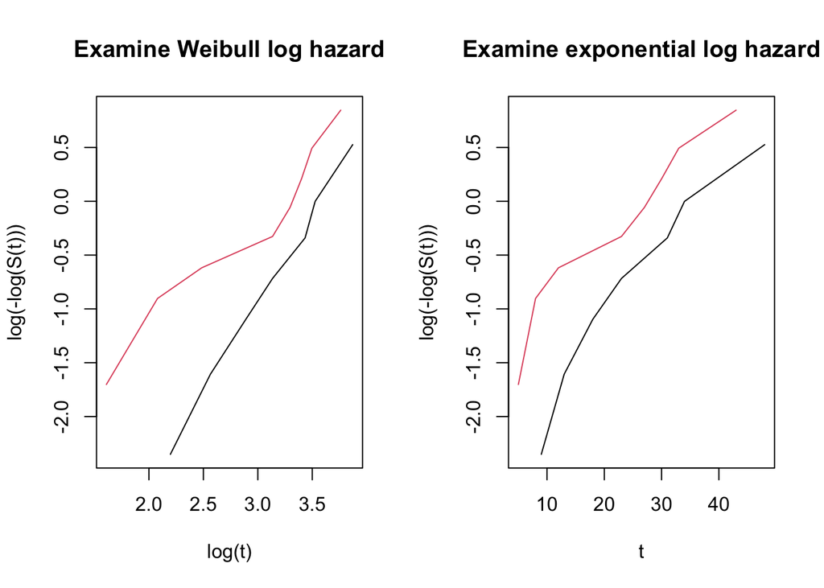

```r
lfitsurv<-survfit(Surv(time, status) ~ x, data=aml)

# Extract survival curves (probably an easier way to do this but the easy way;
# I knew only worked to plot the x axis as logt and I wanted similar
# plots for two transformations logt and t
# Easy way: plot(lfitsurv,fun="cloglog") to plot against logt

# Convert survival probabilities into matrix
survmat <- matrix(lfitsurv$surv, nrow = 10)
survM <- unique(survmat[, 1])
survNM <- unique(survmat[, 2])

# Extract event times for each group
timeM <- unique(aml$time[aml$x == "Maintained" & aml$status == 1])
timeNM <- unique(aml$time[aml$x == "Nonmaintained" & aml$status == 1])

# Plot log-log survival curves to assess Weibull and Exponential fits
par(mfrow = c(1, 2))

# Weibull log-log plot
plot(
  log(timeM), log(-log(survM)), col = 1,
  xlab = "log(t)", ylab = "log(-log(S(t)))",
  main = "Examine Weibull log hazard", type = "l",
  xlim = c(min(log(c(timeM, timeNM))), max(log(c(timeM, timeNM)))),
  ylim = c(
    min(log(-log(c(survM, survNM[!survNM == 0])))),
    max(log(-log(c(survM, survNM[!survNM == 0]))))
  )
)
points(log(timeNM), log(-log(survNM)), type = "l", col = 2)

# Exponential log-log plot
plot(
  timeM, log(-log(survM)), col = 1,
  xlab = "t", ylab = "log(-log(S(t)))",
  main = "Examine exponential log hazard", type = "l",
  xlim = c(min(c(timeM, timeNM)), max(c(timeM, timeNM))),
  ylim = c(
    min(log(-log(c(survM, survNM[!survNM == 0])))),
    max(log(-log(c(survM, survNM[!survNM == 0]))))
  )
)
points(timeNM, log(-log(survNM)), type = "l", col = 2)
```

```r
# Fit Weibull model
lfitW <- survreg(Surv(time, status) ~ x, dist = 'weibull', data = aml)
summary(lfitW)
```

```
##
## Call:
## survreg(formula = Surv(time, status) ~ x, data = aml, dist = "weibull")
##                 Value Std. Error     z      p
## (Intercept)     4.109      0.300 13.70 <2e-16
## xNonmaintained -0.929      0.383 -2.43  0.015
## Log(scale)     -0.235      0.178 -1.32  0.188
##
## Scale= 0.791
##
## Weibull distribution
## Loglik(model)= -80.5   Loglik(intercept only)= -83.2
##  Chisq= 5.31 on 1 degrees of freedom, p= 0.021
## Number of Newton-Raphson Iterations: 5
## n= 23
```

```r
lfitE1 <- survreg(Surv(time, status) ~ x, dist = 'weibull', scale = 1, data = aml)
lfitE2 <- survreg(Surv(time, status) ~ x, dist = "exponential", data = aml)
summary(lfitE1)
```

```
##
## Call:
## survreg(formula = Surv(time, status) ~ x, data = aml, dist = "weibull",
##     scale = 1)
##                 Value Std. Error     z      p
## (Intercept)     4.101      0.378 10.85 <2e-16
## xNonmaintained -0.958      0.483 -1.98  0.048
##
## Scale fixed at 1
##
## Weibull distribution
## Loglik(model)= -81.3   Loglik(intercept only)= -83.3
##  Chisq= 4.06 on 1 degrees of freedom, p= 0.044
## Number of Newton-Raphson Iterations: 4
## n= 23
```

```r
summary(lfitE2)
```

```
##
## Call:
## survreg(formula = Surv(time, status) ~ x, data = aml, dist = "exponential")
##                 Value Std. Error     z      p
## (Intercept)     4.101      0.378 10.85 <2e-16
## xNonmaintained -0.958      0.483 -1.98  0.048
##
## Scale fixed at 1
##
## Exponential distribution
## Loglik(model)= -81.3   Loglik(intercept only)= -83.3
##  Chisq= 4.06 on 1 degrees of freedom, p= 0.044
## Number of Newton-Raphson Iterations: 4
## n= 23
```

```r
lfitcox <- coxph(Surv(time, status) ~ x, data = aml)
summary(lfitcox)
```

```
## Call:
## coxph(formula = Surv(time, status) ~ x, data = aml)
##
##   n= 23, number of events= 18
##
##                  coef exp(coef) se(coef)     z Pr(>|z|)
## xNonmaintained 0.9155    2.4981   0.5119 1.788   0.0737 .
## ---
## Signif. codes:  0 '***' 0.001 '**' 0.01 '*' 0.05 '.' 0.1 ' ' 1
##
##                exp(coef) exp(-coef) lower .95 upper .95
## xNonmaintained     2.498     0.4003    0.9159     6.813
##
## Concordance= 0.619  (se = 0.063 )
## Likelihood ratio test= 3.38  on 1 df,   p=0.07
## Wald test            = 3.2  on 1 df,   p=0.07
## Score (logrank) test = 3.42  on 1 df,   p=0.06
```

## Parameter estimates

We can get both the acceleration parameter and Cox HR from the Weibull and exponential models.

```r
# Weibull acceleration factor and Hazard Ratio comparisons
library(SurvRegCensCov)
ConvertWeibull(lfitW, conf.level = 0.95)
```

```
## $vars
##                   Estimate          SE
## lambda         0.005543889 0.005698291
## gamma          1.264295329 0.225328411
## xNonmaintained 1.174962258 0.523035033
##
## $HR
##                      HR      LB       UB
## xNonmaintained 3.238021 1.16164 9.025845
##
## $ETR
##                      ETR        LB        UB
## xNonmaintained 0.3948136 0.1865546 0.8355611
```

```r
# Hazard Ratio from Weibull model
HR <- exp(-lfitW$coef[2] / lfitW$scale)
HR
```

```
## xNonmaintained
##       3.238021
```

```r
# Exponential acceleration factor
accCI <- confint(lfitE2)[2, ]
c(AF = exp(coef(lfitE2)[2]),
  lower = exp(accCI[1]),
  upper = exp(accCI[2]))
```

```
## AF.xNonmaintained       lower.2.5 %      upper.97.5 %
##         0.3836235         0.1487149         0.9895912
```

```r
# Exponential Hazard Ratio
HRCI <- exp(c(-accCI[2], -accCI[1]))
c(HR = exp(-coef(lfitE2)[2]),
  lower = HRCI[1],
  upper = HRCI[2])
```

```
## HR.xNonmaintained      lower.97.5 %       upper.2.5 %
##          2.606723          1.010518          6.724275
```

```r
# Cox HR
summary(lfitcox)$conf.int
```

```
##                exp(coef) exp(-coef) lower .95 upper .95
## xNonmaintained  2.498105  0.4003034 0.9159073  6.813496
```

## With parametric distributions you can estimate mean survival

```r
# Mean survival 1/lambda
# Maintained mean survival
1/exp(-lfitE2$coef[1])
```

```
## (Intercept)
##    60.42857
```

```r
# Nonmaintained mean survival
1/exp(-(lfitE2$coef[1]+lfitE2$coef[2]))
```

```
## (Intercept)
##    23.18182
```

```r
# Nonmaintained mean survival
# Confidence intervals from add_ci
library(ciTools)
add_ci(aml, lfitE2, alpha = 0.05, names = c("lower", "upper"))
```

```
##    time status             x mean_pred    lower     upper
## 1     9      1    Maintained  60.42857 28.80835 126.75534
## 2    13      1    Maintained  60.42857 28.80835 126.75534
## 3    13      0    Maintained  60.42857 28.80835 126.75534
## 4    18      1    Maintained  60.42857 28.80835 126.75534
## 5    23      1    Maintained  60.42857 28.80835 126.75534
## 6    28      0    Maintained  60.42857 28.80835 126.75534
## 7    31      1    Maintained  60.42857 28.80835 126.75534
## 8    34      1    Maintained  60.42857 28.80835 126.75534
## 9    45      0    Maintained  60.42857 28.80835 126.75534
## 10   48      1    Maintained  60.42857 28.80835 126.75534
## 11  161      0    Maintained  60.42857 28.80835 126.75534
## 12    5      1 Nonmaintained  23.18182 12.83809  41.85954
## 13    5      1 Nonmaintained  23.18182 12.83809  41.85954
## 14    8      1 Nonmaintained  23.18182 12.83809  41.85954
## 15    8      1 Nonmaintained  23.18182 12.83809  41.85954
## 16   12      1 Nonmaintained  23.18182 12.83809  41.85954
## 17   16      0 Nonmaintained  23.18182 12.83809  41.85954
## 18   23      1 Nonmaintained  23.18182 12.83809  41.85954
## 19   27      1 Nonmaintained  23.18182 12.83809  41.85954
## 20   30      1 Nonmaintained  23.18182 12.83809  41.85954
## 21   33      1 Nonmaintained  23.18182 12.83809  41.85954
## 22   43      1 Nonmaintained  23.18182 12.83809  41.85954
## 23   45      1 Nonmaintained  23.18182 12.83809  41.85954
```

```r
# Works for Weibull too - values an exercise
add_ci(aml, lfitW, alpha = 0.05, names = c("lower", "upper"))
```

```
##    time status             x mean_pred    lower     upper
## 1     9      1    Maintained  56.56687 31.45933 101.71263
## 2    13      1    Maintained  56.56687 31.45933 101.71263
## 3    13      0    Maintained  56.56687 31.45933 101.71263
## 4    18      1    Maintained  56.56687 31.45933 101.71263
## 5    23      1    Maintained  56.56687 31.45933 101.71263
## 6    28      0    Maintained  56.56687 31.45933 101.71263
## 7    31      1    Maintained  56.56687 31.45933 101.71263
## 8    34      1    Maintained  56.56687 31.45933 101.71263
## 9    45      0    Maintained  56.56687 31.45933 101.71263
## 10   48      1    Maintained  56.56687 31.45933 101.71263
## 11  161      0    Maintained  56.56687 31.45933 101.71263
## 12    5      1 Nonmaintained  22.33337 13.99111  35.64973
## 13    5      1 Nonmaintained  22.33337 13.99111  35.64973
## 14    8      1 Nonmaintained  22.33337 13.99111  35.64973
## 15    8      1 Nonmaintained  22.33337 13.99111  35.64973
## 16   12      1 Nonmaintained  22.33337 13.99111  35.64973
## 17   16      0 Nonmaintained  22.33337 13.99111  35.64973
## 18   23      1 Nonmaintained  22.33337 13.99111  35.64973
## 19   27      1 Nonmaintained  22.33337 13.99111  35.64973
## 20   30      1 Nonmaintained  22.33337 13.99111  35.64973
## 21   33      1 Nonmaintained  22.33337 13.99111  35.64973
## 22   43      1 Nonmaintained  22.33337 13.99111  35.64973
## 23   45      1 Nonmaintained  22.33337 13.99111  35.64973
```